# Hatton et al. Scaling Laws: Reconstruction and Extended Synthesis

## 3.4 Extended Fig 4: Predator–Prey Scaling (unchanged)

> **Note:** No additional paired predator–prey body mass data are available in the current compiled datasets to augment the Hatton et al. 2015 predator–prey figure. Extended Fig 4 is identical to Fig 4 (Part 1) above.

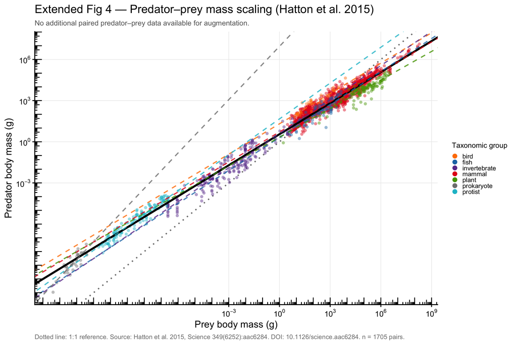

**Extended Fig 4.** Predator body mass vs. prey body mass (Hatton et al. 2015). No augmenting dataset available in current compiled files.

```r
print(p_fig4 +
  labs(title = "Extended Fig 4 — Predator–prey mass scaling (Hatton et al. 2015)",
       subtitle = "No additional paired predator–prey data available for augmentation."))
```

# 4 Regression Summary Table

Combined OLS log-log slopes for all figures and all datasets.

```r
# Assemble all fits
all_fits <- rbindlist(list(
  fit_m[,     .(Figure = "Fig 1 — Metabolic rate (H2019)",        Dataset = "Hatton 2019",
               Group = group, N = n, Slope = slope,
               CI_lo = ci_lo, CI_hi = ci_hi, R2 = r2)],
  fit_g[,     .(Figure = "Fig 2 — Growth rate (H2019)",           Dataset = "Hatton 2019",
               Group = group, N = n, Slope = slope,
               CI_lo = ci_lo, CI_hi = ci_hi, R2 = r2)],
  fit_mort[,  .(Figure = "Fig 3 — Mortality rate (H2019)",        Dataset = "Hatton 2019",
               Group = group, N = n, Slope = slope,
               CI_lo = ci_lo, CI_hi = ci_hi, R2 = r2)],
  fit_pp[,    .(Figure = "Fig 4 — Predator-prey mass (H2015)",    Dataset = "Hatton 2015",
               Group = group, N = n, Slope = slope,
               CI_lo = ci_lo, CI_hi = ci_hi, R2 = r2)],
  if (nrow(fit_ext_metab) > 0)
    fit_ext_metab[, .(Figure = "Ext Fig 1 — Metabolic rate (all)", Dataset = dataset_label,
               Group = group, N = n, Slope = slope,
               CI_lo = ci_lo, CI_hi = ci_hi, R2 = r2)],
  if (nrow(fit_gr_ext) > 0)
    fit_gr_ext[,  .(Figure = "Ext Fig 2 — Growth rate (all)",      Dataset = dataset_label,
               Group = group, N = n, Slope = slope,
               CI_lo = ci_lo, CI_hi = ci_hi, R2 = r2)],
  if (nrow(fit_mort_ext) > 0)
    fit_mort_ext[,.(Figure = "Ext Fig 3 — Mortality rate (all)",   Dataset = dataset_label,
               Group = group, N = n, Slope = slope,
               CI_lo = ci_lo, CI_hi = ci_hi, R2 = r2)]
), fill = TRUE)

all_fits[, `95% CI` := sprintf("[%.3f, %.3f]", CI_lo, CI_hi)]
all_fits[, `:=`(Slope = round(Slope, 3), R2 = round(R2, 3),
                CI_lo = NULL, CI_hi = NULL)]

if (requireNamespace("kableExtra", quietly = TRUE)) {
  knitr::kable(
    all_fits,
    col.names = c("Figure", "Dataset", "Group", "N", "Slope", "R²", "95% CI"),
    caption   = "Table 2. OLS log-log regression slopes for all figures and datasets.",
    format    = "html"
  ) |>
    kableExtra::kable_styling(
      bootstrap_options = c("striped", "hover", "condensed"),
      full_width = TRUE, font_size = 12
    ) |>
    kableExtra::collapse_rows(columns = 1:2, valign = "top")
} else {
  knitr::kable(all_fits,
    col.names = c("Figure", "Dataset", "Group", "N", "Slope", "R²", "95% CI"),
    caption   = "Table 2. OLS log-log regression slopes for all figures and datasets.")
}
```

Table 2. OLS log-log regression slopes for all figures and datasets.

| Figure | Dataset | Group | N | Slope | R² | 95% CI |
| --- | --- | --- | --- | --- | --- | --- |
| Fig 1 — Metabolic rate (H2019) | Hatton 2019 | All | 8098 | 0.943 | 0.961 | [0.938, 0.947] |
|  |  | mammal | 1059 | 0.716 | 0.955 | [0.707, 0.725] |
|  |  | protist | 365 | 0.885 | 0.897 | [0.854, 0.916] |
|  |  | plant | 755 | 0.744 | 0.924 | [0.729, 0.759] |
|  |  | invertebrate | 4559 | 0.824 | 0.838 | [0.814, 0.835] |
|  |  | amphibian | 176 | 0.825 | 0.732 | [0.750, 0.900] |
|  |  | fish | 268 | 0.810 | 0.741 | [0.752, 0.868] |
|  |  | reptile | 172 | 0.733 | 0.787 | [0.675, 0.790] |
|  |  | bird | 492 | 0.660 | 0.956 | [0.647, 0.672] |
|  |  | prokaryote | 252 | 1.153 | 0.762 | [1.073, 1.234] |
| Fig 2 — Growth rate (H2019) |  | All | 1140 | -0.257 | 0.879 | [-0.263, -0.252] |
|  |  | mammal | 674 | -0.257 | 0.514 | [-0.276, -0.238] |
|  |  | protist | 46 | -0.093 | 0.149 | [-0.161, -0.026] |
|  |  | invertebrate | 9 | -0.361 | 0.482 | [-0.694, -0.027] |
|  |  | fish | 25 | -0.279 | 0.326 | [-0.453, -0.106] |
|  |  | bird | 337 | -0.310 | 0.482 | [-0.344, -0.275] |
|  |  | prokaryote | 48 | 0.164 | 0.040 | [-0.074, 0.401] |
| Fig 3 — Mortality rate (H2019) |  | All | 4866 | -0.229 | 0.559 | [-0.235, -0.224] |
|  |  | mammal | 1530 | -0.160 | 0.403 | [-0.170, -0.150] |
|  |  | protist | 42 | -0.154 | 0.117 | [-0.289, -0.019] |
|  |  | plant | 335 | -0.289 | 0.715 | [-0.309, -0.269] |
|  |  | invertebrate | 220 | -0.281 | 0.775 | [-0.301, -0.260] |
|  |  | amphibia | 19 | -0.027 | 0.003 | [-0.278, 0.225] |
|  |  | fish | 824 | -0.414 | 0.757 | [-0.431, -0.398] |
|  |  | reptilia | 29 | -0.170 | 0.360 | [-0.259, -0.080] |
|  |  | bird | 1867 | -0.161 | 0.157 | [-0.178, -0.144] |
| Fig 4 — Predator-prey mass (H2015) | Hatton 2015 | All | 1705 | 0.754 | 0.984 | [0.750, 0.759] |
|  |  | mammal | 1061 | 0.729 | 0.912 | [0.715, 0.743] |
|  |  | bird | 33 | 0.737 | 0.864 | [0.630, 0.844] |
|  |  | fish | 108 | 0.801 | 0.832 | [0.732, 0.870] |
|  |  | invertebrate | 197 | 0.828 | 0.889 | [0.786, 0.869] |
|  |  | plant | 132 | 0.695 | 0.804 | [0.635, 0.754] |
|  |  | protist | 137 | 0.870 | 0.932 | [0.830, 0.910] |
|  |  | prokaryote | 37 | 1.295 | 0.788 | [1.064, 1.525] |
| Ext Fig 1 — Metabolic rate (all) | Hatton 2019 | All | 8098 | 0.943 | 0.961 | [0.938, 0.947] |
|  | Hoehler 2023 (PNAS) | All | 10376 | 0.951 | 0.949 | [0.946, 0.955] |
|  | AnimalTraits | All | 1184 | 1.032 | 0.932 | [1.017, 1.048] |
|  | Chown 2007 | All | 346 | 0.805 | 0.830 | [0.766, 0.843] |
|  | Grady 2014 (extant) | All | 115 | 0.836 | 0.835 | [0.767, 0.905] |
|  | Grady 2014 (extinct/mesotherm) | All | 7 | 0.786 | 0.972 | [0.633, 0.939] |
| Ext Fig 2 — Growth rate (all) | Hatton 2019 | All | 3812 | 0.746 | 0.971 | [0.742, 0.750] |
|  | Grady 2014 (extant) | All | 340 | 0.491 | 0.552 | [0.444, 0.538] |
|  | Grady 2014 (extinct/mesotherm) | All | 36 | 0.590 | 0.890 | [0.518, 0.663] |
| Ext Fig 3 — Mortality rate (all) | Hatton 2019 | All | 4866 | -0.229 | 0.559 | [-0.235, -0.224] |

# 5 Data Provenance

## 5.1 Primary sources

**Hatton et al. 2019** — Linking scaling laws across eukaryotes. *PNAS* 116(43):21616–21622. DOI: 10.1073/pnas.1907703116 Data archived at Zenodo: 10.5281/zenodo.3145281 Note: Metabolic rates in the archived dataset have been temperature-standardised to a common reference temperature using an Arrhenius/Q10 correction (Q10 ≈ 2.81) prior to archiving.

**Hatton et al. 2015** — The predator-prey power law: Biomass scaling across terrestrial and aquatic biomes. *Science* 349(6252):aac6284. DOI: 10.1126/science.aac6284

## 5.2 Augmenting sources

**Hoehler et al. 2023** — The Metabolic Rate of the Biosphere and its Components. *PNAS* 120(25):e2303764120. DOI: 10.1073/pnas.2303764120

**Herberstein et al. 2022 (AnimalTraits)** — AnimalTraits: a curated animal trait database for body mass, metabolic rate and brain size. *Scientific Data* 9:745. DOI: 10.1038/s41597-022-01364-9

**Chown et al. 2007** — Scaling of insect metabolic rate is inconsistent with the nutrient supply network model. *Functional Ecology* 21(2):282–290. DOI: 10.1111/j.1365-2435.2007.01245.x Temperature corrections applied following: Riveros AJ, Enquist BJ (2011). *Journal of Insect Physiology* 57:688–693. DOI: 10.1016/j.jinsphys.2011.01.011

**Grady et al. 2014** — Evidence for mesothermy in dinosaurs. *Science* 344:1268–1272. DOI: 10.1126/science.1253143 Data note: Table S1 extracted from supplementary PDF using `pdftools`. No open data deposit available as of 2026-05-11.

## 5.3 Compilation notes

All compiled CSV files use a standardised schema with provenance columns (`source_id`, `source_doi`, `source_access_date`, `bibliographic_citation`) to ensure traceability. Numeric coercions and quality flags (`qa_flag`, `qa_body_mass_range`, `qa_metabolic_unit_verified`) were applied during the ingestion pipeline. Rows flagged with `qa_flag != "ok"` are retained in this analysis but could be filtered for stricter analyses.

*Document generated: 2026-05-11 16:07:26.46144* *Session info: R 4.6.0, data.table 1.18.4, ggplot2 4.0.3*